# SpotiData

2023-09-29

# 1. Business Understanding

Este modelo se va a centrar en realizar un análisis de las canciones que han sido hit entre los años 2000-2022 en la plataforma de Spotify, con el objetivo de determinar qué canción será un hit de máxima popularidad.

# 2. Data Understanding

## 2.1. Descripción de los datos obtenidos de Spotify (Obtenidos via Kaggle)

*Variables cualitativas*

- playlist_url: dirección de la playlist que contiene los hits de cada año
- track_id: id de la canción en Spotify
- track_name: nombre de la canción
- album: álbum al que pertenece la canción
- artist_id: id del artista que realiza la canción
- artist_genres: géneros musicales a los que está asociado el artista que realiza la canción

*Variables cuantitativas*

- year: año de la canción
- track_popularity: popularidad de la canción en una escala de 0-100
- artist_popularity: popularidad del artista de la canción en una escala de 0-100
- danceability: capacidad de una canción de ser bailable en escala de 0-1
- energy: medida en escala de 0-1 que representa una medida perceptual de la intensidad y actividad de la canción
- key: clave musical en la que se encuentra la canción, en notación estándar de las notas. Por ejemplo 0 = C, 1 = C♯/D♭, 2 = D
- loudness: volumen general de la canción medido en decibelios (dB)
- mode: modalidad (mayor o menor) de la canción. La modalidad “mayor” está representada por 1 y la modalidad “menor” por 0
- speechiness: presencia de palabras habladas en la canción respecto a la duración de esta, en escala de 0-1
- acousticness: medida de confianza en escala de 0-1 de la acústica de la canción
- instrumentalness: presencia de instrumentos en la canción respecto a la duración de esta, en escala de 0-1
- liveness: medida de la identificación de sonidos o señales que indican la existencia de un público o audiencia en la grabación musical de la canción
- valence: medida en escala de 0-1 que describe la positividad musical que transmite la canción
- tempo: velocidad y ritmo estimado de la canción en pulsaciones por minuto (BPM)
- duration_ms: duración de la canción en milisegundos
- time_signature: compás o ritmo estimado de la canción

## 2.2. Paquetes importados

```r
library(dplyr)
```

```r
library(ggplot2)
library(MASS)
library(graphics)
library(ellipse)   # Correlaciones
```

## 2.3. Importación de datos

```r
#str(datosSPOTIFY)

# Seleccion datos David:
#"C:\\Users\\David\\Desktop\\playlist_2010to2022.csv"

# Ruben:
# "C:\\Users\\ruben_zbu59h5\\OneDrive\\Escritorio\\4º Matematicas\\Primer cuatri\\Mineria de Datos\\Trabajo\\MDAT\\playlist_2010to2022.csv"

# Isma:
#C:\\UNIVERSIDAD\\4º\\Minería de datos\\MDAT\\datos\\playlist_2010to2022.csv


datosBase <- read.csv("C:\\Users\\ruben_zbu59h5\\OneDrive\\Escritorio\\4º Matematicas\\Primer cuatri\\Mineria de Datos\\Trabajo\\MDAT\\playlist_2010to2022.csv", sep=",", dec=".")
```

## 2.4. Limpiar datos

Veamos cuantos NA tenemos, para buscar solución e interpretación de estos.

```r
sum(is.na(datosBase))
```

```
## [1] 13
```

```r
which(is.na(datosBase)) #sacamos los NA
```

```
##  [1] 23448 25748 28048 30348 32648 34948 37248 39548 41848 44148 46448 48748
## [13] 51048
```

```r
#tenemos que eliminar la fila 448 (cancion: These Words , Unwritten)
datosModificados = datosBase[-c(448), ]
```

Como solo teníamos una canción con sus variables NA, en cómputo queneral es algo que no está aportando nada ya que simplemente es un error o falta de información en la base de datos. Al ser mínimo, podemos poner la media de cada variable o simplemente quitarlo ya que no es significativo. Hemos optado por quitarlo.

Veamos un pequeño resumen de nuestros datos (con un ejemplo de visualización):

```r
dim(datosModificados) # vemos las dimensiones de nuestros datos (numero de registros y variables)
```

```
## [1] 2299   23
```

```r
summary(datosModificados) # resumen de los datos por cada variable
```

```
##  playlist_url            year        track_id          track_name
##  Length:2299        Min.   :2000   Length:2299        Length:2299
##  Class :character   1st Qu.:2005   Class :character   Class :character
##  Mode  :character   Median :2011   Mode  :character   Mode  :character
##                     Mean   :2011
##                     3rd Qu.:2017
##                     Max.   :2022
##  track_popularity    album            artist_id         artist_name
##  Min.   :  0.00   Length:2299        Length:2299        Length:2299
##  1st Qu.: 66.00   Class :character   Class :character   Class :character
##  Median : 72.00   Mode  :character   Mode  :character   Mode  :character
##  Mean   : 70.94
##  3rd Qu.: 79.00
##  Max.   :100.00
##  artist_genres      artist_popularity  danceability        energy
##  Length:2299        Min.   : 29.00    Min.   :0.1620   Min.   :0.0519
##  Class :character   1st Qu.: 65.00    1st Qu.:0.5720   1st Qu.:0.5860
##  Mode  :character   Median : 74.00    Median :0.6710   Median :0.7120
##                     Mean   : 72.87    Mean   :0.6601   Mean   :0.6930
##                     3rd Qu.: 82.00    3rd Qu.:0.7595   3rd Qu.:0.8200
##                     Max.   :100.00    Max.   :0.9750   Max.   :0.9990
##       key            loudness            mode         speechiness
##  Min.   : 0.000   Min.   :-21.107   Min.   :0.0000   Min.   :0.0225
##  1st Qu.: 2.000   1st Qu.: -6.824   1st Qu.:0.0000   1st Qu.:0.0380
##  Median : 5.000   Median : -5.511   Median :1.0000   Median :0.0568
##  Mean   : 5.278   Mean   : -5.784   Mean   :0.5985   Mean   :0.0978
##  3rd Qu.: 8.000   3rd Qu.: -4.364   3rd Qu.:1.0000   3rd Qu.:0.1155
##  Max.   :11.000   Max.   : -0.276   Max.   :1.0000   Max.   :0.5760
##   acousticness       instrumentalness       liveness          valence
##  Min.   :0.0000129   Min.   :0.0000000   Min.   :0.02100   Min.   :0.0377
##  1st Qu.:0.0165000   1st Qu.:0.0000000   1st Qu.:0.08995   1st Qu.:0.3605
##  Median :0.0689000   Median :0.0000000   Median :0.11900   Median :0.5400
##  Mean   :0.1576892   Mean   :0.0137663   Mean   :0.17262   Mean   :0.5351
##  3rd Qu.:0.2230000   3rd Qu.:0.0000544   3rd Qu.:0.22000   3rd Qu.:0.7220
##  Max.   :0.9780000   Max.   :0.9850000   Max.   :0.84300   Max.   :0.9740
##      tempo         duration_ms     time_signature
##  Min.   : 60.02   Min.   : 97393   Min.   :1.000
##  1st Qu.: 98.57   1st Qu.:200180   1st Qu.:4.000
##  Median :120.00   Median :221653   Median :4.000
##  Mean   :120.51   Mean   :226034   Mean   :3.982
##  3rd Qu.:137.03   3rd Qu.:245950   3rd Qu.:4.000
##  Max.   :210.86   Max.   :688453   Max.   :5.000
```

```r
head(datosModificados) # Imprimimos algunos datos como ejemplo
```

```
##                                               playlist_url year
## 1 https://open.spotify.com/playlist/37i9dQZF1DWUZv12GM5cFk 2000
## 2 https://open.spotify.com/playlist/37i9dQZF1DWUZv12GM5cFk 2000
## 3 https://open.spotify.com/playlist/37i9dQZF1DWUZv12GM5cFk 2000
## 4 https://open.spotify.com/playlist/37i9dQZF1DWUZv12GM5cFk 2000
## 5 https://open.spotify.com/playlist/37i9dQZF1DWUZv12GM5cFk 2000
## 6 https://open.spotify.com/playlist/37i9dQZF1DWUZv12GM5cFk 2000
##                 track_id           track_name track_popularity
## 1 3AJwUDP919kvQ9QcozQPxg               Yellow               91
## 2 2m1hi0nfMR9vdGC8UcrnwU All The Small Things               84
## 3 3y4LxiYMgDl4RethdzpmNe              Breathe               69
## 4 60a0Rd6pjrkxjPbaKzXjfq           In the End               88
## 5 62bOmKYxYg7dhrC6gH9vFn          Bye Bye Bye               74
## 6 5Mmk2ii6laakqfeCT7OnVD           Thong Song               73
##                           album              artist_id artist_name
```

[output cut: 34 more lines]

Las variables playlist_url, track_id y artist_id son candidatas a que las limpiemos.

```r
frecuencia_nombres <- table(datosModificados$track_name)

mean(frecuencia_nombres)
```

```
## [1] 1.084434
```

```r
nombres_frecuencia_mayor_1 <- names(frecuencia_nombres[frecuencia_nombres > 1])

# Muestra los nombres con frecuencia mayor que 1
print(nombres_frecuencia_mayor_1)
```

```
##   [1] "34+35"
##   [2] "A Moment Like This"
##   [3] "A Thousand Years"
##   [4] "Ain't It Fun"
##   [5] "All My Friends (feat. Tinashe & Chance the Rapper)"
##   [6] "All Time Low"
##   [7] "Angel"
##   [8] "Baby"
##   [9] "Bad Blood"
##  [10] "bad guy"
##  [11] "Beautiful"
##  [12] "Beggin'"
##  [13] "Better Now"
##  [14] "Blinding Lights"
##  [15] "Bodak Yellow"
```

[output cut: 153 more lines]

Salen bastantes nombres repetidos, hemos visto que es porque aparecen varios años. Haciendo una investigación sobre la fuente, se debe a que estos hits se extraen de playlists creadas por Spotify de cada año. Por esa razón, si una canción aparece en la playlist de top hits 2021 y a la vez en la de 2022, la canción aparece 2 veces en la base de datos, solo con el año cambiado.

## 2.5. Definición de la variable Target

```r
quantile(datosModificados$track_popularity, 0.05)
```

```
##   5%
## 54.9
```

```r
quantile(datosModificados$track_popularity, 0.5)
```

```
## 50%
##  72
```

```r
quantile(datosModificados$track_popularity, 0.95)
```

```
## 95%
##  86
```

Vamos a dividir nuestra variable objetivo (target) en 4 dependiendo de los cuantiles;

```r
#quantile(datosModificados$track_popularity)


datosModificados = datosModificados %>% mutate(target = if_else(track_popularity <= 54, 0, ifelse(54 < track_popularity  & track_popularity <= 72, 1, ifelse(track_popularity > 72 & track_popularity < 86, 2, 3 )))) #quantile(datosmodificados$track_popularity, 0.05)

#View(cbind(datos$track_popularity,datos$target))
```

## 2.6. Filtrar géneros

Debido a que la variable artist_genres nos da varios géneros en una misma variable cualitativa, vamos a quedarnos con el género más significativo para cada caso.

Esto sería un trabajo a realizar junto a un experto en el tema, pero como no contamos con uno, lo que hemos hecho ha sido ver todos los géneros que aparecen y, tras previa búsqueda de información sobre cada género, hemos agrupado cada subgénero en su género principal.

Además, hemos creado un género llamado ‘Otros’, donde se guardan los que NO pertenecen a alguno de los principales.

Como dato a tener en cuenta, la mayoría de subgeneros se incluirían en Pop, ya que al ser una base de datos de hits, la propia definición de este género nos obligaría a meterlos, resultando en una pérdida importante de información.

Para solucionar esto, si cualquiera de los otros géneros aparece en esa observación, nos quedamos con el otro, en vez de coger siempre Pop. Todo esto es posible gracias a que estamos haciendo esta construcción mediante else-ifs.

```r
for (i in datosModificados$artist_genres) {
  if( grepl("rap",i) ){
    datosModificados$artist_genres[datosModificados$artist_genres == i] <- 'rap'
  }
  else if( grepl("r&b",i) ||  grepl("soul",i) ){
    datosModificados$artist_genres[datosModificados$artist_genres == i] <- 'r&b'
  }
    else if( grepl("urban contemporary",i) ||  grepl("hop",i) || grepl("urbano latino",i) || grepl("reggaeton",i)  ){
    datosModificados$artist_genres[datosModificados$artist_genres == i] <- 'urban'
    }
    else if( grepl("metal",i) ){
    datosModificados$artist_genres[datosModificados$artist_genres == i] <- 'metal'
      }
  else if( grepl("rock",i) ){
    datosModificados$artist_genres[datosModificados$artist_genres == i] <- 'rock'
      }
  else if( grepl("edm",i) ||  grepl("trance",i) ||  grepl("electronica",i) ||  grepl("dance",i) ||  grepl("house",i)  || grepl("uk garage",i)){
    datosModificados$artist_genres[datosModificados$artist_genres == i] <- 'edm'
  }
  else if( grepl("k pop",i) ){
    datosModificados$artist_genres[datosModificados$artist_genres == i] <- 'k pop'
  }
      else if ( grepl("country",i)){
    datosModificados$artist_genres[datosModificados$artist_genres == i] <- 'country'
  }
  else if ( grepl("pop",i) || grepl("boy band",i) || grepl("mellow",i)){
    datosModificados$artist_genres[datosModificados$artist_genres == i] <- 'pop'
  }
  else ( datosModificados$artist_genres[datosModificados$artist_genres == i] <- 'otros')

}



datosModificados$artist_genres <- as.factor(datosModificados$artist_genres)
```

Veamos cómo quedan repartidos los géneros, para verificar que la separación realizada tiene algún sentido.

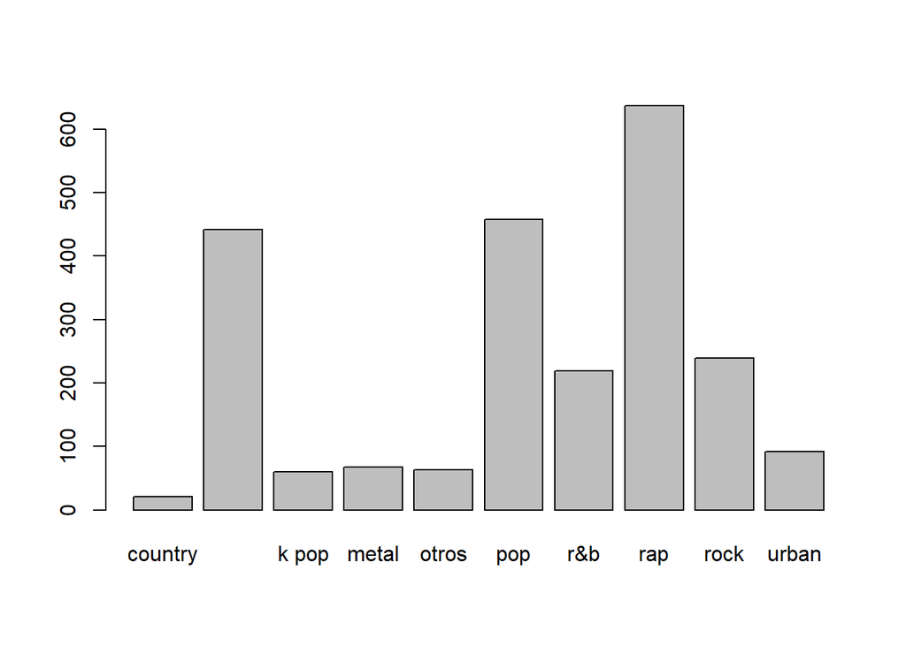

```r
barplot(table(datosModificados$artist_genres))
```

```r
table(datosModificados$artist_genres)
```

```
##
## country     edm   k pop   metal   otros     pop     r&b     rap    rock   urban
##      21     442      60      68      63     458     219     637     239      92
```

## 2.7. Clasificación en Train, Test y Validación

Dividimos los datos en diferentes tablas que utilizaremos para entrenar, hacer pruebas y validar resultado.

```r
n_total= dim(datosModificados)[1]
n_train = n_total * .5     # La mitad de los datos son para train
n_test = n_total *.25      # 1/4 para probar

indices_totales = seq(1:n_total)
indices_train = sample(indices_totales, n_train)
indices_test = sample(indices_totales[-indices_train],n_test)

datos = datosModificados[indices_train,]    # Los datos de train, como son los más utilizados los llamamos datos
datos_test = datosModificados[indices_test,]
datos_validation = datosModificados[-c(indices_test,indices_train),]
```

# 3. Analisis Exploratorio

Para comenzar con nuestro anánisis, lo primero que vamos a hacer es crear un Data Frame solo con las variables cuantitativas. Y por otro lado, uno con las variables continuas.

```r
datosCuant = cbind( year = datos$year, track_popularity = datos$track_popularity, artist_popularity = datos$artist_popularity ,danceability = datos$danceability,energy = datos$energy,loudness = datos$loudness, speechiness = datos$speechiness,acousticness =  datos$acousticness, instrumentalness = datos$instrumentalness, liveness = datos$liveness,valence = datos$valence,tempo= datos$tempo,duration_ms = datos$duration_ms)

datosCont = cbind( danceability = datos$danceability,energy = datos$energy,loudness = datos$loudness, speechiness = datos$speechiness,acousticness =  datos$acousticness, instrumentalness = datos$instrumentalness, liveness = datos$liveness,valence = datos$valence,tempo= datos$tempo,duration_ms = datos$duration_ms)
```

Veamos una comparación general de todas nuestras variables cuantivas:

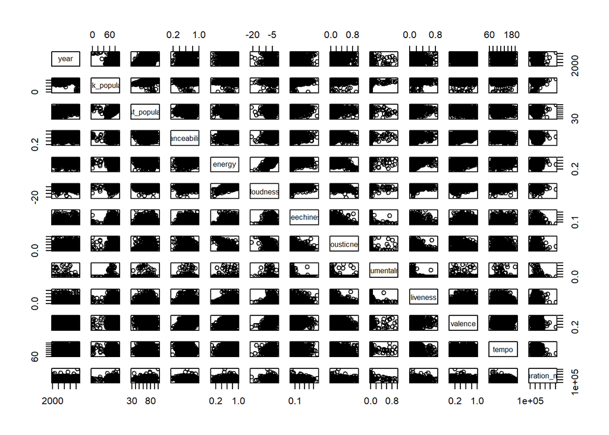

```r
pairs(datosCuant)
```

Ahora, una comparación general de todas nuestras variables CONTINUAS:

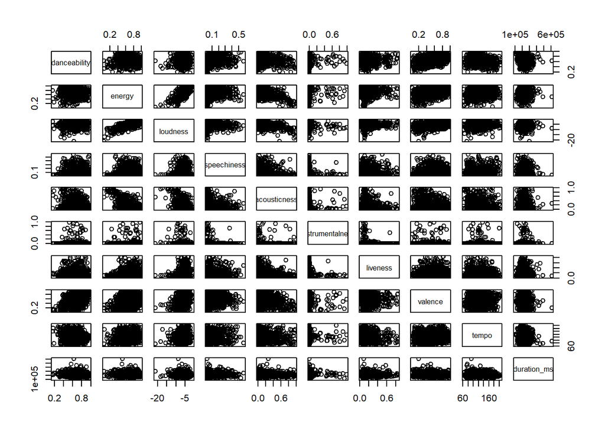

```r
pairs(datosCont)
```

Veamos la correlación existente entre las variables cuantitativas:

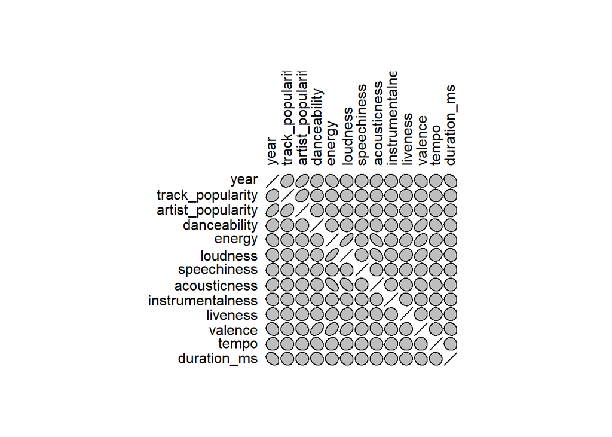

```r
plotcorr(cor(datosCuant)) # cuanto mas se asemejen las figuras a una elipse mayor es la correlacion
```

En las variables que no son continuas (year y popularities) no podemos apreciar mucha correlación con las demás, por ello, veamos solo las continuas:

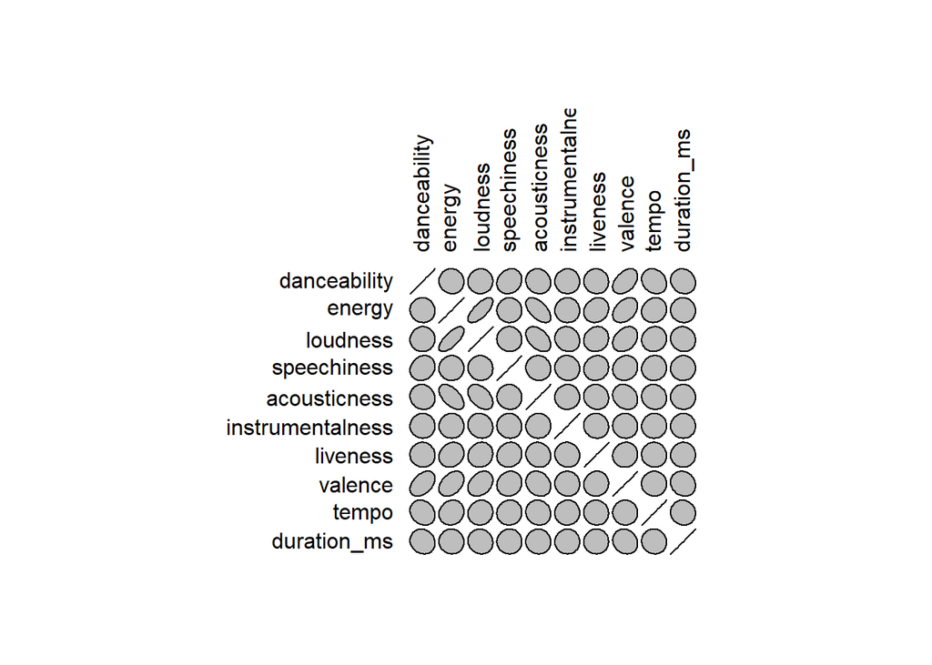

```r
plotcorr(cor(datosCont)) # cuanto mas se asemejen las figuras a una elipse mayor es la correlacion
```

```r
#ggplot(datosCuant, aes(x= lprice, fill=color)) + geom_density(alpha=0.3)
```

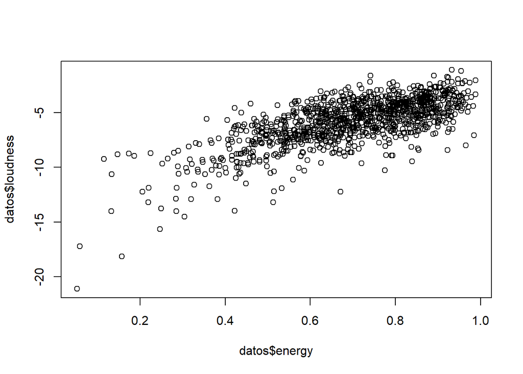

```r
plot(datos$energy , datos$loudness)
```

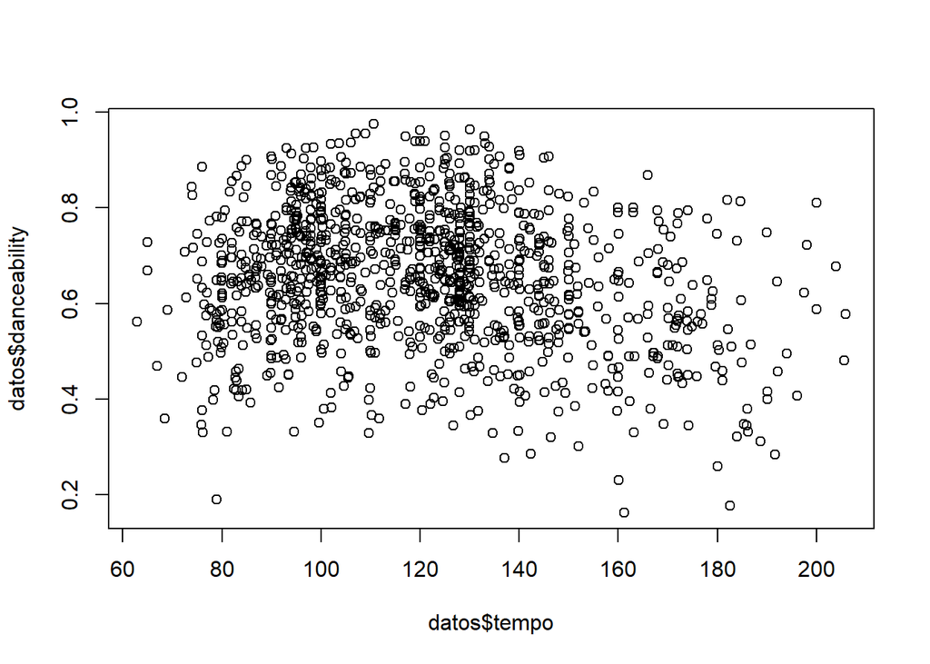

```r
plot(datos$tempo , datos$danceability)
```

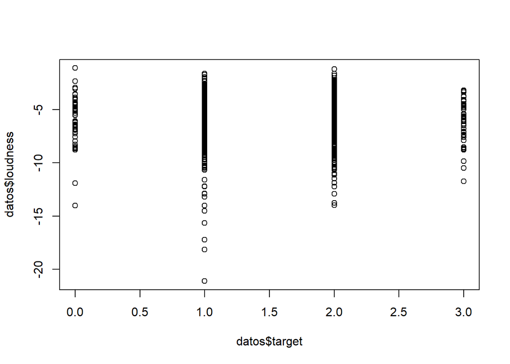

```r
plot( datos$target, datos$loudness)
```

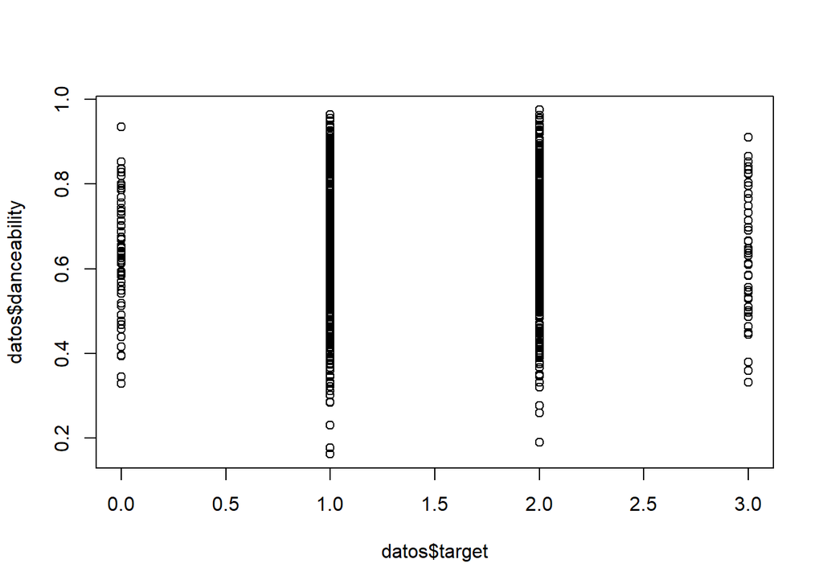

```r
plot(datos$target, datos$danceability)
```

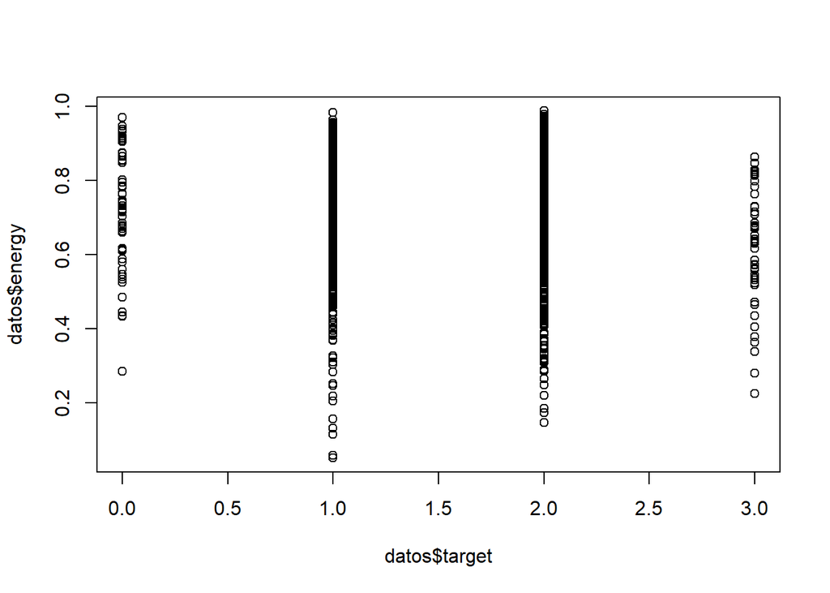

```r
plot(datos$target, datos$energy)
```

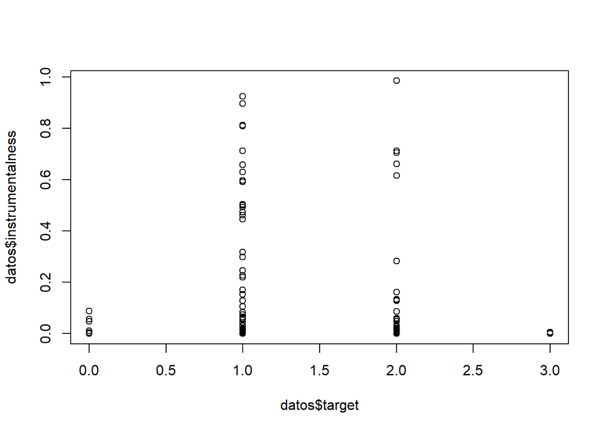

```r
plot(datos$target, datos$instrumentalness)
```

Vamos a hacer el estudio de PCA de las variables continuas, primero lo haremos con éstas escaladas y despues sin escalar, para ver si la diferencia nos infiere alguna conclusión.

# Variables continuas ESCALADAS

Primero escalamos los datos continuos

```r
datosContEscalados = scale(datosCont)
n = dim(datosContEscalados)[1]
p = dim(datosContEscalados)[2]
```

Una vez tenemos los datos escalados, hacemos un análisis de las componentes principales para éstos.

```r
analisisPCAEscalados <- prcomp(datosContEscalados, scale= TRUE)

cov(datosContEscalados)
```

```
##                   danceability       energy    loudness  speechiness
## danceability      1.0000000000 -0.043572669  0.01836274  0.167580438
## energy           -0.0435726689  1.000000000  0.70960824  0.006839743
## loudness          0.0183627367  0.709608241  1.00000000 -0.027143095
## speechiness       0.1675804382  0.006839743 -0.02714310  1.000000000
## acousticness     -0.0987327944 -0.563584817 -0.44144153 -0.046802700
## instrumentalness  0.0008624629 -0.002611893 -0.12221571 -0.055112741
## liveness         -0.0297051439  0.161461907  0.10760612  0.096310439
## valence           0.4309762841  0.393524214  0.31583196  0.110299426
## tempo            -0.1973938171  0.112964847  0.07526958  0.046447491
## duration_ms      -0.1195550725 -0.033483313 -0.07976814  0.013420863
##                  acousticness instrumentalness     liveness      valence
## danceability      -0.09873279     0.0008624629 -0.029705144  0.430976284
## energy            -0.56358482    -0.0026118931  0.161461907  0.393524214
## loudness          -0.44144153    -0.1222157139  0.107606115  0.315831965
## speechiness       -0.04680270    -0.0551127414  0.096310439  0.110299426
## acousticness       1.00000000     0.0203657741 -0.088713507 -0.195026634
## instrumentalness   0.02036577     1.0000000000 -0.057711832 -0.041212373
## liveness          -0.08871351    -0.0577118318  1.000000000  0.061060161
## valence           -0.19502663    -0.0412123731  0.061060161  1.000000000
## tempo             -0.08287713     0.0240152992 -0.034893722 -0.007524324
## duration_ms       -0.01490258     0.0066735711  0.005755451 -0.143227431
##                         tempo  duration_ms
## danceability     -0.197393817 -0.119555073
## energy            0.112964847 -0.033483313
## loudness          0.075269579 -0.079768136
## speechiness       0.046447491  0.013420863
## acousticness     -0.082877127 -0.014902582
## instrumentalness  0.024015299  0.006673571
## liveness         -0.034893722  0.005755451
## valence          -0.007524324 -0.143227431
## tempo             1.000000000 -0.059773534
## duration_ms      -0.059773534  1.000000000
```

```r
analisisPCAEscalados
```

```
## Standard deviations (1, .., p=10):
##  [1] 1.5651621 1.2105300 1.0553745 1.0244383 1.0003458 0.9653197 0.8478864
##  [8] 0.7889681 0.6508039 0.4734280
##
## Rotation (n x k) = (10 x 10):
##                          PC1         PC2         PC3         PC4         PC5
## danceability      0.13757914 -0.68705621  0.07900489  0.08630440 -0.10115137
## energy            0.55677917  0.21032643  0.03079185  0.08153934 -0.05909092
## loudness          0.52089739  0.17161514  0.03458612  0.09382807  0.14418093
## speechiness       0.06694021 -0.29689469 -0.43533938 -0.53557592 -0.37883832
## acousticness     -0.45222443 -0.13772827  0.02294024 -0.10296330  0.18917559
## instrumentalness -0.06974823  0.03527481  0.44179603  0.12912054 -0.74154145
## liveness          0.14689557  0.03816838 -0.57517529 -0.07063801  0.02937567
## valence           0.38799204 -0.42453402  0.13183650 -0.02083078 -0.01054340
## tempo             0.07665183  0.34328667  0.22273598 -0.70791334 -0.13853719
## duration_ms      -0.08882831  0.21534452 -0.45668888  0.39549857 -0.46490029
##                          PC6         PC7        PC8          PC9        PC10
## danceability     -0.09102659 -0.15124907 -0.4021254  0.483262926 -0.24226820
## energy            0.02669662  0.04817539  0.2205020 -0.069077721 -0.76042409
## loudness         -0.04995400  0.08213063  0.2948611  0.597615453  0.46378657
## speechiness      -0.15968006  0.42618190  0.2823810 -0.002911189  0.02481751
## acousticness      0.13203649 -0.33156434  0.6567064  0.329439483 -0.24989343
## instrumentalness  0.44400135  0.06986286  0.1226890  0.075608582  0.09676793
## liveness          0.73415907 -0.25477472 -0.1790900  0.053708865  0.03778918
## valence          -0.02584074 -0.48127704  0.2939774 -0.509228440  0.27069436
## tempo            -0.14637571 -0.45370690 -0.2369767  0.149826090 -0.02125965
## duration_ms      -0.43284450 -0.41136720  0.0449687  0.075095765  0.01952549
```

Veamos la información acumulada que nos va aportando cada componente principal

```r
summary(analisisPCAEscalados)
```

```
## Importance of components:
##                          PC1    PC2    PC3    PC4    PC5     PC6     PC7
## Standard deviation     1.565 1.2105 1.0554 1.0244 1.0003 0.96532 0.84789
## Proportion of Variance 0.245 0.1465 0.1114 0.1050 0.1001 0.09318 0.07189
## Cumulative Proportion  0.245 0.3915 0.5029 0.6078 0.7079 0.80109 0.87298
##                            PC8     PC9    PC10
## Standard deviation     0.78897 0.65080 0.47343
## Proportion of Variance 0.06225 0.04235 0.02241
## Cumulative Proportion  0.93523 0.97759 1.00000
```

```r
#hacer varias componentes principales incluyendo popularidad o no
```

```r
#clusters2.datosCont = kmeans(datosContEscalados, centers=2, nstart=25)

#Inicializamos el vector
SSW <- vector(mode = "numeric", length = 15)


#Variabilidad de todos los datos, es decir, todos los datos como un único cluster
SSW[1] <- (n - 1) * sum(apply(datosContEscalados,2,var))

#Variabilidad de cada modelo, desde 2 clusters hasta 15 clusters
for (i in 2:15) SSW[i] <- sum(kmeans(datosContEscalados,centers=i,nstart=25)$withinss)
```

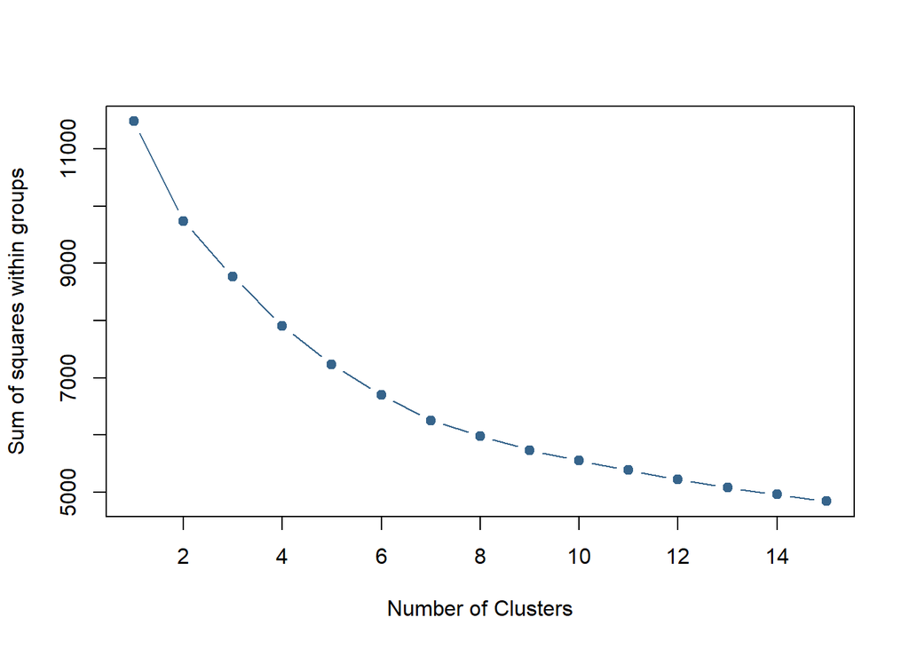

```r
#Dibujamos un gráfico con el resultado
plot(1:15, SSW, type="b", xlab="Number of Clusters", ylab="Sum of squares within groups",pch=19, col="steelblue4")
```

Se aprecia que a partir de 5 o 6 hay un “codo” por lo que nos vamos a quedar con 5 clusters.

# Variables continuas NO ESCALADAS

Veamos que si no hubiesemos escalado los datos, los resultados cambiarian, pero únicamente los de la elección del número de clusters, el resto de datos (PCA) son idénticos.

```r
nCont = dim(datosCont)[1]
pCont = dim(datosCont)[2]
```

Análisis de las componentes principales para los datos sin escalar.

```r
analisisPCA_NoEscalados <- prcomp(datosCont, scale= TRUE)

cov(datosCont)
```

```
##                   danceability        energy      loudness   speechiness
## danceability      1.981376e-02 -1.028974e-03  5.575839e-03  0.0022862397
## energy           -1.028974e-03  2.814582e-02  2.568118e-01  0.0001112146
## loudness          5.575839e-03  2.568118e-01  4.653489e+00 -0.0056749712
## speechiness       2.286240e-03  1.112146e-04 -5.674971e-03  0.0093935534
## acousticness     -2.822654e-03 -1.920344e-02 -1.934084e-01 -0.0009212949
## instrumentalness  1.109663e-05 -4.005250e-05 -2.409815e-02 -0.0004882410
## liveness         -5.644289e-04  3.656546e-03  3.133433e-02  0.0012600344
## valence           1.399168e-02  1.522690e-02  1.571370e-01  0.0024655925
## tempo            -7.759193e-01  5.292364e-01  4.534280e+00  0.1257119908
## duration_ms      -7.288235e+02 -2.432799e+02 -7.452288e+03 56.3334373470
##                   acousticness instrumentalness      liveness       valence
## danceability     -2.822654e-03     1.109663e-05 -0.0005644289  1.399168e-02
## energy           -1.920344e-02    -4.005250e-05  0.0036565464  1.522690e-02
## loudness         -1.934084e-01    -2.409815e-02  0.0313343278  1.571370e-01
## speechiness      -9.212949e-04    -4.882410e-04  0.0012600344  2.465592e-03
## acousticness      4.125016e-02     3.780776e-04 -0.0024321851 -9.135657e-03
## instrumentalness  3.780776e-04     8.354771e-03 -0.0007120758 -8.688164e-04
## liveness         -2.432185e-03    -7.120758e-04  0.0182216699  1.901013e-03
## valence          -9.135657e-03    -8.688164e-04  0.0019010131  5.319443e-02
## tempo            -4.700532e-01     6.129920e-02 -0.1315348650 -4.846186e-02
## duration_ms      -1.310826e+02     2.641779e+01 33.6468412167 -1.430639e+03
##                          tempo   duration_ms
## danceability     -7.759193e-01 -7.288235e+02
## energy            5.292364e-01 -2.432799e+02
## loudness          4.534280e+00 -7.452288e+03
## speechiness       1.257120e-01  5.633344e+01
## acousticness     -4.700532e-01 -1.310826e+02
## instrumentalness  6.129920e-02  2.641779e+01
## liveness         -1.315349e-01  3.364684e+01
## valence          -4.846186e-02 -1.430639e+03
## tempo             7.798283e+02 -7.229018e+04
## duration_ms      -7.229018e+04  1.875607e+09
```

```r
analisisPCA_NoEscalados
```

```
## Standard deviations (1, .., p=10):
##  [1] 1.5651621 1.2105300 1.0553745 1.0244383 1.0003458 0.9653197 0.8478864
##  [8] 0.7889681 0.6508039 0.4734280
##
## Rotation (n x k) = (10 x 10):
##                          PC1         PC2         PC3         PC4         PC5
## danceability      0.13757914 -0.68705621  0.07900489  0.08630440 -0.10115137
## energy            0.55677917  0.21032643  0.03079185  0.08153934 -0.05909092
## loudness          0.52089739  0.17161514  0.03458612  0.09382807  0.14418093
## speechiness       0.06694021 -0.29689469 -0.43533938 -0.53557592 -0.37883832
## acousticness     -0.45222443 -0.13772827  0.02294024 -0.10296330  0.18917559
## instrumentalness -0.06974823  0.03527481  0.44179603  0.12912054 -0.74154145
## liveness          0.14689557  0.03816838 -0.57517529 -0.07063801  0.02937567
## valence           0.38799204 -0.42453402  0.13183650 -0.02083078 -0.01054340
## tempo             0.07665183  0.34328667  0.22273598 -0.70791334 -0.13853719
## duration_ms      -0.08882831  0.21534452 -0.45668888  0.39549857 -0.46490029
##                          PC6         PC7        PC8          PC9        PC10
## danceability     -0.09102659 -0.15124907 -0.4021254  0.483262926 -0.24226820
## energy            0.02669662  0.04817539  0.2205020 -0.069077721 -0.76042409
## loudness         -0.04995400  0.08213063  0.2948611  0.597615453  0.46378657
## speechiness      -0.15968006  0.42618190  0.2823810 -0.002911189  0.02481751
## acousticness      0.13203649 -0.33156434  0.6567064  0.329439483 -0.24989343
## instrumentalness  0.44400135  0.06986286  0.1226890  0.075608582  0.09676793
## liveness          0.73415907 -0.25477472 -0.1790900  0.053708865  0.03778918
## valence          -0.02584074 -0.48127704  0.2939774 -0.509228440  0.27069436
## tempo            -0.14637571 -0.45370690 -0.2369767  0.149826090 -0.02125965
## duration_ms      -0.43284450 -0.41136720  0.0449687  0.075095765  0.01952549
```

Veamos la información acumulada que nos va aportando cada componente principal

```r
summary(analisisPCA_NoEscalados)
```

```
## Importance of components:
##                          PC1    PC2    PC3    PC4    PC5     PC6     PC7
## Standard deviation     1.565 1.2105 1.0554 1.0244 1.0003 0.96532 0.84789
## Proportion of Variance 0.245 0.1465 0.1114 0.1050 0.1001 0.09318 0.07189
## Cumulative Proportion  0.245 0.3915 0.5029 0.6078 0.7079 0.80109 0.87298
##                            PC8     PC9    PC10
## Standard deviation     0.78897 0.65080 0.47343
## Proportion of Variance 0.06225 0.04235 0.02241
## Cumulative Proportion  0.93523 0.97759 1.00000
```

```r
#hacer varias componentes principales incluyendo popularidad o no
```

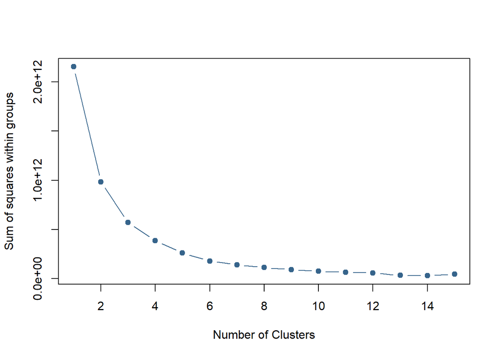

```r
#Inicializamos el vector
SSW2 <- vector(mode = "numeric", length = 15)

#Variabilidad de todos los datos, es decir, todos los datos como un único cluster
SSW2[1] <- (n - 1) * sum(apply(datosCont,2,var))

#Variabilidad de cada modelo, desde 2 clusters hasta 15 clusters
for (i in 2:15) SSW2[i] <- sum(kmeans(datosCont,centers=i,nstart=25)$withinss)

#Dibujamos un gráfico con el resultado
plot(1:15, SSW2, type="b", xlab="Number of Clusters", ylab="Sum of squares within groups",pch=19, col="steelblue4")
```

# Volvemos a los datos escalados para calcular los cluster

Calculamos los 5 cluster, para 25 casos y se queda con el mejor

```r
# k-means para 5 grupos y 25 arranques diferentes

clusters5.datosContEscalados <- kmeans(datosContEscalados, 5, nstart = 25)

clusters5.datosContEscalados
```

```
## K-means clustering with 5 clusters of sizes 412, 20, 193, 336, 188
##
## Cluster means:
##   danceability       energy    loudness speechiness acousticness
## 1   0.52079863  0.444582887  0.44737892  -0.3438681  -0.26145135
## 2   0.08021618 -0.005604768 -0.61934675  -0.3865380   0.01021666
## 3  -0.31227366 -1.423298814 -1.24982064  -0.3964727   1.45568144
## 4  -0.75023773  0.323756213  0.25783664  -0.3449667  -0.44970368
## 5   0.51157092 -0.091178035 -0.09229206   1.8182578  -0.11878968
##   instrumentalness    liveness    valence       tempo duration_ms
## 1       -0.1407155 -0.08473719  0.8028502 -0.12681564 -0.26396562
## 2        7.0418439 -0.33731906 -0.2418062  0.07702321 -0.06361841
## 3       -0.1013636 -0.26070085 -0.7879369 -0.16984651  0.15143865
## 4       -0.1047903  0.08663414 -0.6551693  0.34852806  0.17267951
## 5       -0.1494115  0.33438455  0.2461200 -0.17881635  0.12116079
```

[output cut: 43 more lines]

Podemos ver en la ejecución anterior a que cluster pertenece cada observación.

Ahora veamos cuales son los centroides

```r
centroides = aggregate(datosContEscalados,by=list(clusters5.datosContEscalados$cluster),FUN=mean)

t(centroides)
```

```
##                         [,1]         [,2]       [,3]        [,4]        [,5]
## Group.1           1.00000000  2.000000000  3.0000000  4.00000000  5.00000000
## danceability      0.52079863  0.080216185 -0.3122737 -0.75023773  0.51157092
## energy            0.44458289 -0.005604768 -1.4232988  0.32375621 -0.09117803
## loudness          0.44737892 -0.619346752 -1.2498206  0.25783664 -0.09229206
## speechiness      -0.34386811 -0.386538022 -0.3964727 -0.34496670  1.81825782
## acousticness     -0.26145135  0.010216664  1.4556814 -0.44970368 -0.11878968
## instrumentalness -0.14071554  7.041843856 -0.1013636 -0.10479031 -0.14941147
## liveness         -0.08473719 -0.337319057 -0.2607008  0.08663414  0.33438455
## valence           0.80285020 -0.241806176 -0.7879369 -0.65516933  0.24612000
## tempo            -0.12681564  0.077023206 -0.1698465  0.34852806 -0.17881635
## duration_ms      -0.26396562 -0.063618409  0.1514387  0.17267951  0.12116079
```

Ahora representamos los cluster

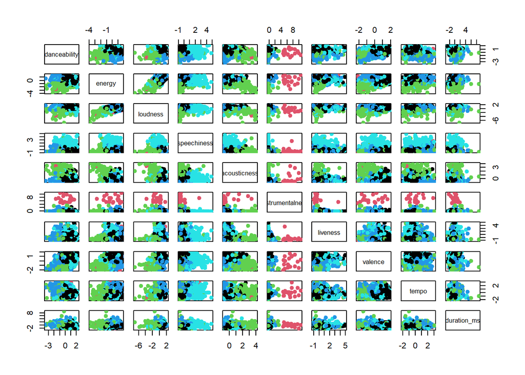

```r
# Dibujamos los clusters en el scatterplot (variables 2a2)

nk=5 # nk es el numero de clusters
pairs(datosContEscalados, col= clusters5.datosContEscalados$cluster,pch=19)

points(clusters5.datosContEscalados$centers, col = 1:nk, pch = 19, cex=2)
```

Ahora lo hacemos con 6 clusters

```r
# k-means para 6 grupos y 25 arranques diferentes

clusters6.datosContEscalados <- kmeans(datosContEscalados, 6, nstart = 25)

clusters6.datosContEscalados
```

```
## K-means clustering with 6 clusters of sizes 20, 368, 144, 163, 289, 165
##
## Cluster means:
##   danceability       energy   loudness speechiness acousticness
## 1   0.08021618 -0.005604768 -0.6193468 -0.38653802   0.01021666
## 2   0.56693259  0.355694397  0.3951267 -0.33745188  -0.21325319
## 3  -0.10824303  0.593605381  0.4242128 -0.03043087  -0.37649209
## 4   0.58878911 -0.232145753 -0.2099039  1.91630901  -0.06137329
## 5  -0.75652716  0.233872812  0.2035681 -0.34195945  -0.43121824
## 6  -0.43627150 -1.490982439 -1.3255951 -0.46810297   1.61887041
##   instrumentalness   liveness    valence       tempo duration_ms
## 1       7.04184386 -0.3373191 -0.2418062  0.07702321 -0.06361841
## 2      -0.13754989 -0.3806064  0.7825725 -0.16020327 -0.22955668
## 3      -0.15692264  1.9528922  0.3027307 -0.16155106 -0.05844667
## 4      -0.14644865 -0.1204278  0.1870935 -0.08579055 -0.04532025
```

[output cut: 45 more lines]

```r
centroides = aggregate(datosContEscalados,by=list(clusters6.datosContEscalados$cluster),FUN=mean)

t(centroides)
```

```
##                          [,1]       [,2]        [,3]        [,4]        [,5]
## Group.1           1.000000000  2.0000000  3.00000000  4.00000000  5.00000000
## danceability      0.080216185  0.5669326 -0.10824303  0.58878911 -0.75652716
## energy           -0.005604768  0.3556944  0.59360538 -0.23214575  0.23387281
## loudness         -0.619346752  0.3951267  0.42421280 -0.20990394  0.20356810
## speechiness      -0.386538022 -0.3374519 -0.03043087  1.91630901 -0.34195945
## acousticness      0.010216664 -0.2132532 -0.37649209 -0.06137329 -0.43121824
## instrumentalness  7.041843856 -0.1375499 -0.15692264 -0.14644865 -0.09985123
## liveness         -0.337319057 -0.3806064  1.95289225 -0.12042785 -0.23131514
## valence          -0.241806176  0.7825725  0.30273065  0.18709352 -0.76068606
## tempo             0.077023206 -0.1602033 -0.16155106 -0.08579055  0.40457526
## duration_ms      -0.063618409 -0.2295567 -0.05844667 -0.04532025  0.22166976
##                         [,6]
## Group.1           6.00000000
## danceability     -0.43627150
## energy           -1.49098244
## loudness         -1.32559509
## speechiness      -0.46810297
## acousticness      1.61887041
## instrumentalness -0.09026376
## liveness         -0.29046741
## valence          -0.83273773
## tempo            -0.13491332
## duration_ms       0.22721324
```

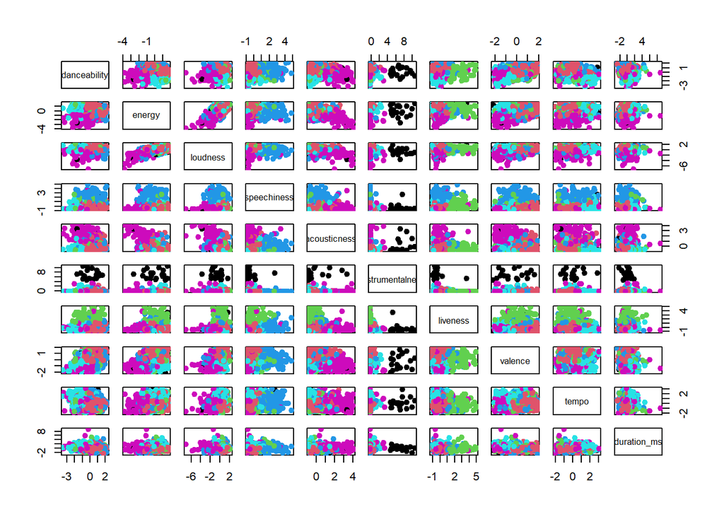

```r
# Dibujamos los clusters en el scatterplot (variables 2a2)

nk=6 # nk es el numero de clusters
pairs(datosContEscalados, col= clusters6.datosContEscalados$cluster,pch=19)

points(clusters6.datosContEscalados$centers, col = 1:nk, pch = 19, cex=2)
```

Esto era representando los cluster con todos los datos.

Ahora repetimos el proceso pero con las PCA.

```r
# Guardamos el vector con el cluster correspondiente a cada país
clusters5.datosContEscalados_PCA <- clusters5.datosContEscalados$cluster
# Vamos a hacer PCA para poder graficar los clusters en 2dimensiones!
library(cluster)
```

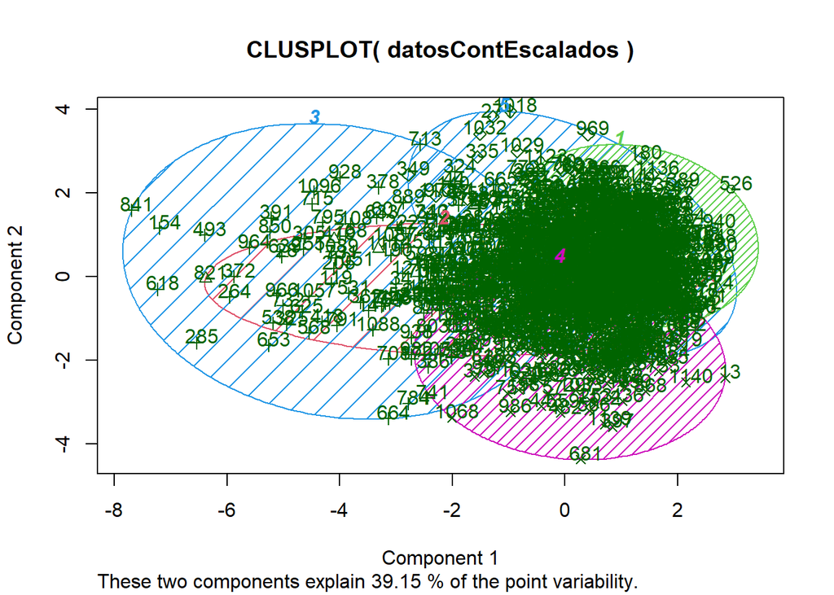

```r
clusplot(datosContEscalados, clusters5.datosContEscalados_PCA, color=TRUE, shade=TRUE, labels=2,lines=0)
```

# Volvemos a los datos NO escalados para calcular los cluster

```r
# k-means para 5 grupos y 25 arranques diferentes

clusters3.datosCont <- kmeans(datosCont, 5, nstart = 25)

clusters3.datosCont
```

```
## K-means clustering with 5 clusters of sizes 147, 33, 167, 397, 405
##
## Cluster means:
##   danceability    energy  loudness speechiness acousticness instrumentalness
## 1    0.6986190 0.6830748 -5.835973  0.11573333    0.1864897       0.02286577
## 2    0.6292727 0.6742424 -6.601636  0.14076667    0.1730109       0.02370184
## 3    0.6341856 0.6672150 -6.223982  0.10602216    0.1603658       0.02036706
## 4    0.6499446 0.6962393 -5.746350  0.09795340    0.1542059       0.01379861
## 5    0.6617778 0.7110926 -5.649741  0.09689778    0.1518293       0.01180266
##    liveness   valence    tempo duration_ms
## 1 0.1911102 0.5603129 123.9093    166406.3
## 2 0.2145788 0.4330909 121.1782    362848.6
## 3 0.1659934 0.4684156 118.2749    280791.0
## 4 0.1703705 0.5289096 119.5097    236280.1
## 5 0.1737509 0.5565484 121.6078    204123.1
```

[output cut: 43 more lines]

Podemos ver en la ejecución anterior a que cluster pertenece cada observación.

Ahora veamos cuales son los centroides

```r
centroides = aggregate(datosCont,by=list(clusters3.datosCont$cluster),FUN=mean)

t(centroides)
```

```
##                           [,1]          [,2]          [,3]          [,4]
## Group.1           1.000000e+00  2.000000e+00  3.000000e+00  4.000000e+00
## danceability      6.986190e-01  6.292727e-01  6.341856e-01  6.499446e-01
## energy            6.830748e-01  6.742424e-01  6.672150e-01  6.962393e-01
## loudness         -5.835973e+00 -6.601636e+00 -6.223982e+00 -5.746350e+00
## speechiness       1.157333e-01  1.407667e-01  1.060222e-01  9.795340e-02
## acousticness      1.864897e-01  1.730109e-01  1.603658e-01  1.542059e-01
## instrumentalness  2.286577e-02  2.370184e-02  2.036706e-02  1.379861e-02
## liveness          1.911102e-01  2.145788e-01  1.659934e-01  1.703705e-01
## valence           5.603129e-01  4.330909e-01  4.684156e-01  5.289096e-01
## tempo             1.239093e+02  1.211782e+02  1.182749e+02  1.195097e+02
## duration_ms       1.664063e+05  3.628486e+05  2.807910e+05  2.362801e+05
##                           [,5]
## Group.1           5.000000e+00
## danceability      6.617778e-01
## energy            7.110926e-01
## loudness         -5.649741e+00
## speechiness       9.689778e-02
## acousticness      1.518293e-01
## instrumentalness  1.180266e-02
## liveness          1.737509e-01
## valence           5.565484e-01
## tempo             1.216078e+02
## duration_ms       2.041231e+05
```

Ahora representamos los cluster

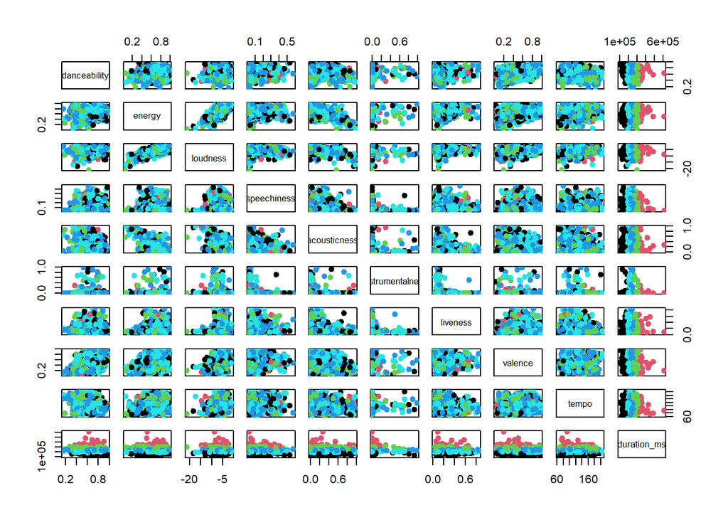

```r
# Dibujamos los clusters en el scatterplot (variables 2a2)

nk=3 # nk es el numero de clusters
pairs(datosCont, col= clusters3.datosCont$cluster,pch=19)

points(clusters3.datosCont$centers, col = 1:nk, pch = 19, cex=2)
```

Ahora lo hacemos con 4 clusters

```r
# k-means para 4 grupos y 25 arranques diferentes

clusters4.datosCont <- kmeans(datosCont, 4, nstart = 25)

clusters4.datosCont
```

```
## K-means clustering with 4 clusters of sizes 34, 216, 353, 546
##
## Cluster means:
##   danceability    energy  loudness speechiness acousticness instrumentalness
## 1    0.6287941 0.6749118 -6.660941  0.14053824    0.1684929       0.02300473
## 2    0.6312685 0.6739579 -6.179306  0.10745185    0.1638641       0.02011089
## 3    0.6746006 0.6933839 -5.756397  0.10523739    0.1718195       0.01226559
## 4    0.6585220 0.7054945 -5.661874  0.09589414    0.1480575       0.01528752
##    liveness   valence    tempo duration_ms
## 1 0.2180324 0.4343529 121.2244    361598.8
## 2 0.1664352 0.4747796 117.9847    274552.5
## 3 0.1760875 0.5491360 122.8860    183712.5
## 4 0.1746875 0.5477971 120.2873    225920.7
##
## Clustering vector:
```

[output cut: 41 more lines]

```r
centroides = aggregate(datosCont,by=list(clusters4.datosCont$cluster),FUN=mean)

t(centroides)
```

```
##                           [,1]          [,2]          [,3]          [,4]
## Group.1           1.000000e+00  2.000000e+00  3.000000e+00  4.000000e+00
## danceability      6.287941e-01  6.312685e-01  6.746006e-01  6.585220e-01
## energy            6.749118e-01  6.739579e-01  6.933839e-01  7.054945e-01
## loudness         -6.660941e+00 -6.179306e+00 -5.756397e+00 -5.661874e+00
## speechiness       1.405382e-01  1.074519e-01  1.052374e-01  9.589414e-02
## acousticness      1.684929e-01  1.638641e-01  1.718195e-01  1.480575e-01
## instrumentalness  2.300473e-02  2.011089e-02  1.226559e-02  1.528752e-02
## liveness          2.180324e-01  1.664352e-01  1.760875e-01  1.746875e-01
## valence           4.343529e-01  4.747796e-01  5.491360e-01  5.477971e-01
## tempo             1.212244e+02  1.179847e+02  1.228860e+02  1.202873e+02
## duration_ms       3.615988e+05  2.745525e+05  1.837125e+05  2.259207e+05
```

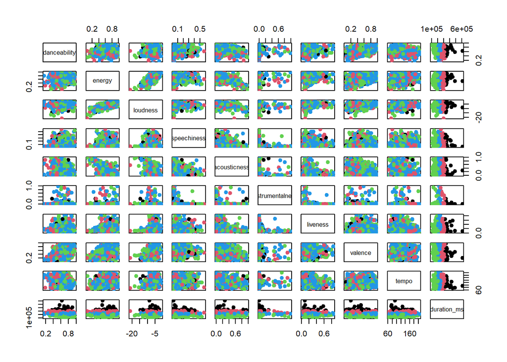

```r
# Dibujamos los clusters en el scatterplot (variables 2a2)

nk=4 # nk es el numero de clusters
pairs(datosCont, col= clusters4.datosCont$cluster,pch=19)

points(clusters4.datosCont$centers, col = 1:nk, pch = 19, cex=2)
```

Esto era representando los cluster con todos los datos.

Ahora repetimos el proceso pero con las PCA.

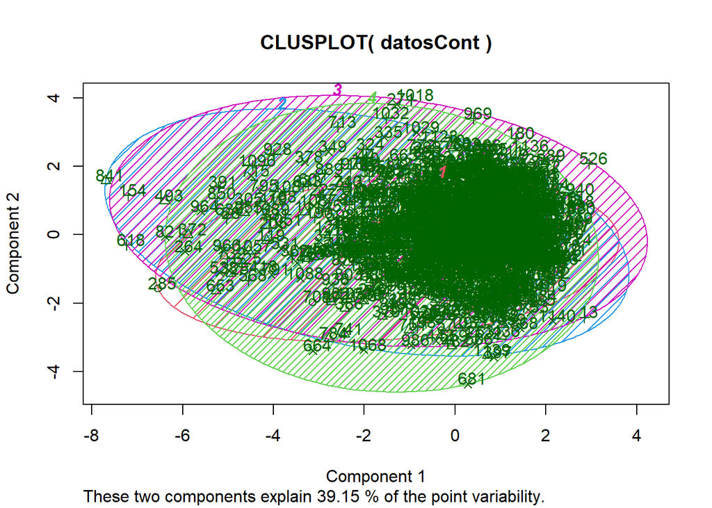

```r
# Guardamos el vector con el cluster correspondiente a cada país
clusters4.datosCont_PCA <- clusters4.datosCont$cluster
# Vamos a hacer PCA para poder graficar los clusters en 2dimensiones!
library(cluster)

clusplot(datosCont, clusters4.datosCont_PCA, color=TRUE, shade=TRUE, labels=2,lines=0)
```

# Que artistas tienen mas popularidad, actuales o antiguos?

# Canciones largas son superhists?

# El instrumental o el nivel de sonido es importante?

# Canciones con un nivel de sonido bajo es posible que sea un superhit?

# Una cancion con poca danzabilidad puede ser superhit?